# Exploring the BRFSS data

## Introduction

### Summary

In this document the author presents an exploratory analysis of the publicly available dataset about Behavioral Risk Factor Surveillance System ([BRFSS](http://www.cdc.gov/brfss/)).

### Abstract/General information about the dataset

*“The Behavioral Risk Factor Surveillance System (BRFSS) is a collaborative project between all of the states in the United States (US) and participating US territories and the Centers for Disease Control and Prevention (CDC). The BRFSS is administered and supported by CDC’s Population Health Surveillance Branch, under the Division of Population Health at the National Center for Chronic Disease Prevention and Health Promotion. BRFSS is an ongoing surveillance system designed to measure behavioral risk factors for the non-institutionalized adult population (18 years of age and older) residing in the US. The BRFSS was initiated in 1984, with 15 states collecting surveillance data on risk behaviors through monthly telephone interviews. Over time, the number of states participating in the survey increased; by 2001, 50 states, the District of Columbia, Puerto Rico, Guam, and the US Virgin Islands were participating in the BRFSS. Today, all 50 states, the District of Columbia, Puerto Rico, and Guam collect data annually and American Samoa, Federated States of Micronesia, and Palau collect survey data over a limited point- in-time (usually one to three months). In this document, the term “state” is used to refer to all areas participating in BRFSS, including the District of Columbia, Guam, and the Commonwealth of Puerto Rico.*

The BRFSS objective is to collect uniform, state-specific data on preventive health practices and risk behaviors that are linked to chronic diseases, injuries, and preventable infectious diseases that affect the adult population. Factors assessed by the BRFSS in 2013 include tobacco use, HIV/AIDS knowledge and prevention, exercise, immunization, health status, healthy days — health-related quality of life, health care access, inadequate sleep, hypertension awareness, cholesterol awareness, chronic health conditions, alcohol consumption, fruits and vegetables consumption, arthritis burden, and seatbelt use. Since 2011, BRFSS conducts both landline telephone- and cellular telephone-based surveys. In conducting the BRFSS landline telephone survey, interviewers collect data from a randomly selected adult in a household. In conducting the cellular telephone version of the BRFSS questionnaire, interviewers collect data from an adult who participates by using a cellular telephone and resides in a private residence or college housing.

Health characteristics estimated from the BRFSS pertain to the non-institutionalized adult population, aged 18 years or older, who reside in the US. In 2013, additional question sets were included as optional modules to provide a measure for several childhood health and wellness indicators, including asthma prevalence for people aged 17 years or younger." Source: <a href=“http://guides.library.duke.edu/c.php?g=289704&p=1930838”>Duke University Data and Visualization Services

## Reproduceability - local setup

### Load packages

The current document makes use of these packages:

```r
library(ggplot2)
library(dplyr)
options(dplyr.width = Inf)
```

### Load data

In this repository, the data file is located in a dedicated directory called ‘data’. Thus, it requires some “extra” effort to load it, which is NOT necessary in case you decide to co-locate the dataset to this R mark-down file.

To load the dataset to the current working environment, you can do as follows:

```r
# Set your working directory to this repo's root BEFORE running next commands; for example, like so: setwd("./dir1/dir2/")
script.dir = getwd()
data.dir = paste(sep="/", script.dir, "data")
data.file = paste(sep="/", data.dir, "brfss2013.RData")
load(data.file)
```

This will store in your global environment dataframe called “brfss2013”.

The dataset contains an extensive amount of variables (330), and observations (491775):

```r
dim(brfss2013)
```

```
## [1] 491775    330
```

To get more meta info about the dataset:

```r
str(brfss2013)
```

```
## 'data.frame':    491775 obs. of  330 variables:
##  $ X_state  : Factor w/ 55 levels "0","Alabama",..: 2 2 2 2 2 2 2 2 2 2 ...
##  $ fmonth   : Factor w/ 12 levels "January","February",..: 1 1 1 1 2 3 3 3 4 4 ...
##  $ idate    : int  1092013 1192013 1192013 1112013 2062013 3272013 3222013 3042013 4242013 4242013 ...
##  $ imonth   : Factor w/ 12 levels "January","February",..: 1 1 1 1 2 3 3 3 4 4 ...
##  $ iday     : Factor w/ 31 levels "1","2","3","4",..: 9 19 19 11 6 27 22 4 24 24 ...
##  $ iyear    : Factor w/ 2 levels "2013","2014": 1 1 1 1 1 1 1 1 1 1 ...
##  $ dispcode : Factor w/ 2 levels "Completed interview",..: 1 1 1 1 1 1 1 1 1 1 ...
##  $ seqno    : int  2013000580 2013000593 2013000600 2013000606 2013000608 2013000630 2013000634 2013000644 2013001305 2013001338 ...
##  $ X_psu    : int  2013000580 2013000593 2013000600 2013000606 2013000608 2013000630 2013000634 2013000644 2013001305 2013001338 ...
##  $ ctelenum : Factor w/ 1 level "Yes": 1 1 1 1 1 1 1 1 1 1 ...
##  $ pvtresd1 : Factor w/ 2 levels "Yes","No": 1 1 1 1 1 1 1 1 1 1 ...
##  $ colghous : Factor w/ 1 level "Yes": NA NA NA NA NA NA NA NA NA NA ...
##  $ stateres : Factor w/ 1 level "Yes": 1 1 1 1 1 1 1 1 1 1 ...
##  $ cellfon3 : Factor w/ 1 level "Not a cellular phone": 1 1 1 1 1 1 1 1 1 1 ...
```

[output cut: 86 more lines]

```r
#summary(brfss2013)
```

## Part 1: About Data collection

Prior to analysing the data, it is essencial that one investigates how the sample data was collected, in order to know its limitations and potential in terms of inference. Namely, we want to know if it is generalizable and if we can prove causality.

The type of this study is “observational”, as oposed to “experiment”, since it consists of survey collection via telephone interviews.

The telephone interviews are conducted through random sampling from adult (aged 18 years or older) US population, as mentioned in the brfss_codebook: “*… interviewers collect data from a randomly selected adult in a household.*”. Moreover it is mentioned that “*…, interviewers collect data from an adult who participates by using a cellular telephone and resides in a private residence or college housing.*”. S ince the data collected depends on voluntary response, there might be an inherent bias involved. For example, some individuals who suffer from a given desease/health condition might be more reluctant to participate in such a survey.

Nonetheless, it is assumed that the sample is representative of the population at hand, given its large sample size (491775 observations) and randomness.

```r
dim(brfss2013)[2]
```

```
## [1] 330
```

We can thus conclude that since this is an observational study which used random sampling, researchers can at best generalize conclusions, although not prove causality. This is due to the fact that no random assignment was used while conducting the study.

## Part 2: Research questions

In this research, we are generally interested in finding more about how the professional level impacts people in the US.

**Research quesion 1:** Regarding “Mental Illness and Stigma” and “Social Context”, does the respondants’ frequency of feeling of depression in the last 30 days vary according to the number of hours they work per week?

In this research question, we are interested in finding out if the depression level reported by the respondats is in any way related to the number of hours worked per week.

- Explanatory variable: “scntlwk1” (How Many Hours Per Week Did You Work); variable type: numerical discrete; data type encoding in dataset: int
- Response variable: “misdeprd” (How Often Feel Depressed Past 30 Days); variable type: categorical ordinal with 5 levels

**Research quesion 2:** Regarding “Healthy Days (Symptoms)” and “Demographics”, does the respondants’ energy level self-perception vary according to level of income?

In this research question we want to analyse if the income level is in any way related to the self perception of energy level.

- Response variable: “income2” (Income Level); variable type: categorical ordinal with 8 levels;
- Response variable: “qlhlth2” (How Many Days Full Of Energy In Past 30 Days); variable type: numerical discrete; data type encoding in dataset: int

**Research quesion 3:** Regarding “Social Context” and “Demographics”, does the respondants’ level of income vary according to the number of hours worked?

In this last research question we are interested in finding out if there is any relationship between income level and number of working hours. In other and less scientific words, does hard work pay off?

- Explanatory variable: “scntlwk1” (How Many Hours Per Week Did You Work); variable type: numerical discrete; data type encoding in dataset: int
- Response variable: “income2” (Income Level); variable type: categorical ordinal with 8 levels;

## Part 3: Exploratory data analysis

**Research quesion 1:** Regarding “Mental Illness and Stigma” and “Social Context”, does the respondants’ frequency of feeling of depression in the last 30 days vary according to the number of hours they work per week?

- Explanatory variable: “scntlwk1” (How Many Hours Per Week Did You Work); variable type: numerical discrete; data type encoding in dataset: int
- Response variable: “misdeprd” (How Often Feel Depressed Past 30 Days); variable type: categorical ordinal with 5 levels

Let us start by analysing the different levels of depression assessment. Since the variable is categorical, we choose the plot function.

```r
table(brfss2013$misdeprd)
```

```
##
##      All     Most     Some A little     None
##      259      539     1567     2539    31202
```

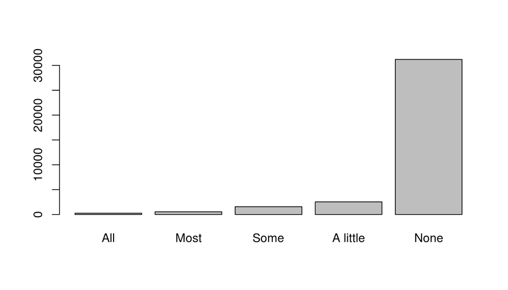

```r
plot(brfss2013$misdeprd)
```

As for the number of hours worked - scntlwk1 variable - we can see that it spans up moreless between 0 and 100 hours, closely centered at 40 with 42 hours as mean - what could be already moreless expected assuming an eight (8) hours per day during five days of the week - and 40 as median.

```r
summary(brfss2013$scntlwk1)
```

```
##    Min. 1st Qu.  Median    Mean 3rd Qu.    Max.    NA's
##       0      40      40      42      48     150  470493
```

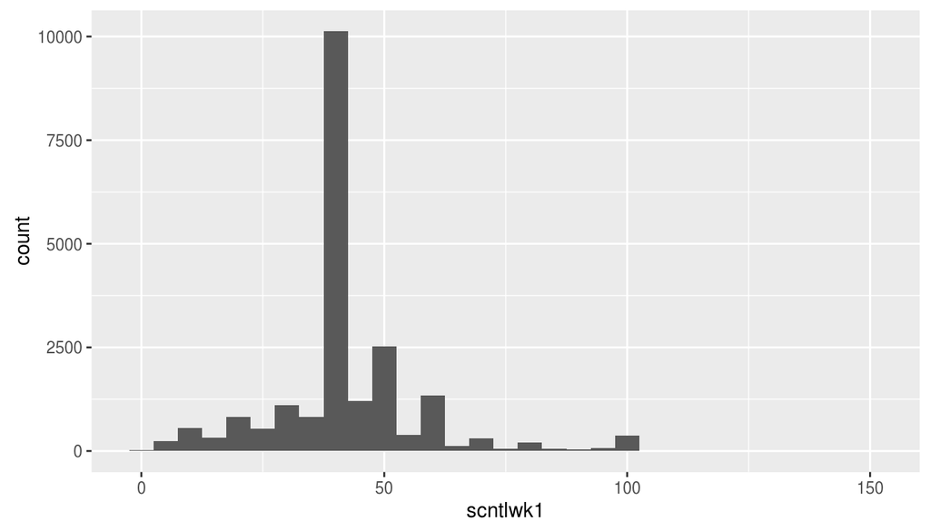

```r
ggplot(data = brfss2013, aes(x = scntlwk1)) +
  geom_histogram(binwidth=5)
```

With a boxplot we can understand that the 150 hours is an outlier, and an individual observation.

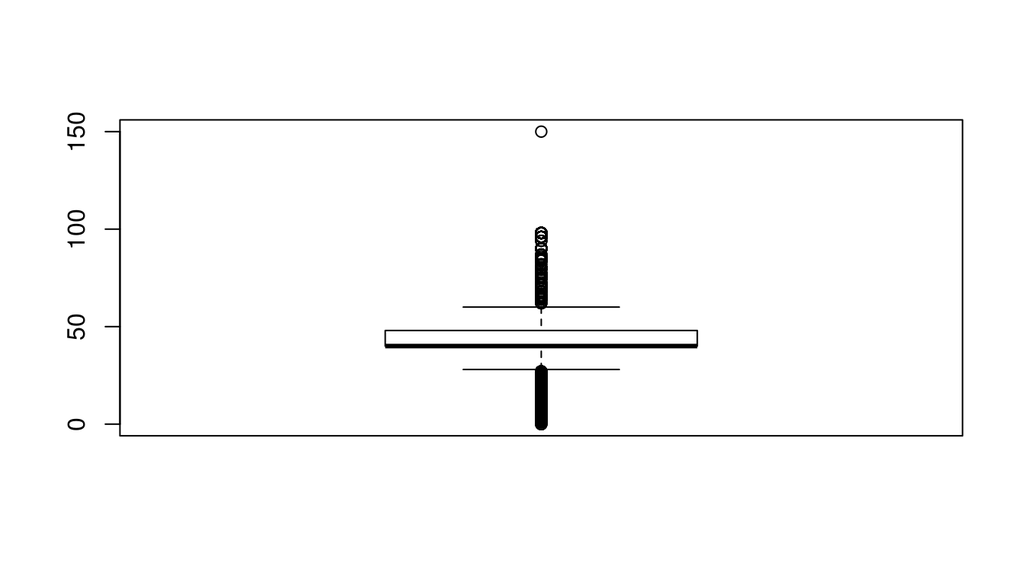

```r
boxplot(brfss2013$scntlwk1)
```

We can see that it is unimodal, relatively symmetric. One would expect that with a bigger sample size this would approximate a normal distribution.

However, a worrying fact is that there are a lot of NA’s - present in both variables.

```r
sum(is.na(brfss2013$misdeprd))
```

```
## [1] 455669
```

```r
sum(is.na(brfss2013$scntlwk1))
```

```
## [1] 470493
```

This is quite limiting both in absolute - 455669 for misdeprd and 470493 for scntlwk1 - and in relative terms - approximately respectively 93% and 96%!

```r
sum(is.na(brfss2013$misdeprd))/length(brfss2013$misdeprd)
```

```
## [1] 0.9265802
```

```r
sum(is.na(brfss2013$scntlwk1))/length(brfss2013$scntlwk1)
```

```
## [1] 0.9567241
```

Let us try to analyse a cleaner dataset, removing NAs for misdeprd and scntlwk1 variables.

```r
brfss2013_without_nas = subset(brfss2013, !is.na(misdeprd))
brfss2013_without_nas = subset(brfss2013_without_nas, !is.na(scntlwk1))
summary(brfss2013_without_nas$misdeprd)
```

```
##      All     Most     Some A little     None
##       19       65      187      304     4797
```

```r
summary(brfss2013_without_nas$scntlwk1)
```

```
##    Min. 1st Qu.  Median    Mean 3rd Qu.    Max.
##    0.00   40.00   40.00   41.21   48.00  150.00
```

Please note that this reduction decreased the number of availbale observations drastically, from 491.775 to a mere 5.372 observations.

Let us try to see how these two variables work with each other. We want to understand if there is any intrinsic pattern between intense labour and the level of depression. Let us plot one variable against the other.

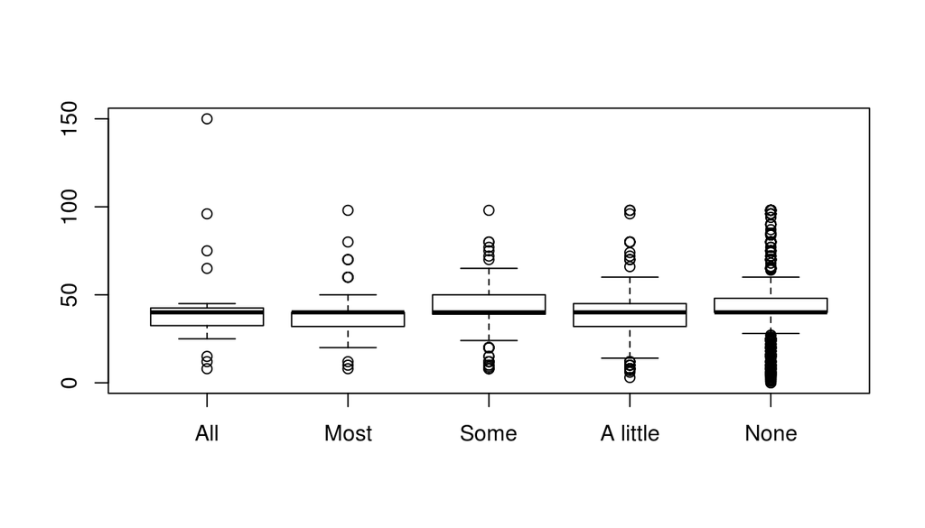

```r
plot(brfss2013_without_nas$misdeprd, brfss2013_without_nas$scntlwk1)
```

It is interesting to note that moreless all depression levels have moreless the same median, the spread/range among observations within each group seems aparently to increase as the level of “depression” decreases.

However, the figures do not hint on more conclusive information.

**Research quesion 2:** Regarding “Healthy Days (Symptoms)” and “Demographics”, does the respondants’ energy level self-perception vary according to level of income?

- Response variable: “income2” (Income Level); variable type: categorical ordinal with 8 levels;
- Response variable: “qlhlth2” (How Many Days Full Of Energy In Past 30 Days); variable type: numerical discrete; data type encoding in dataset: int

Let us start with the income level variable.

```r
summary(brfss2013$income2)
```

```
## Less than $10,000 Less than $15,000 Less than $20,000 Less than $25,000
##             25441             26794             34873             41732
## Less than $35,000 Less than $50,000 Less than $75,000   $75,000 or more
##             48867             61509             65231            115902
##              NA's
##             71426
```

One interesting fact worthy of note is the fact that the income2 variable is left skewed.

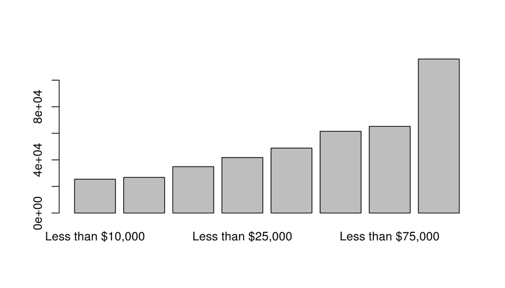

```r
plot(brfss2013$income2)
```

Given the fact that (unfortunetely) the majority of USA population does not earn more than 75.000$ per year, one might speculate on the reason why such skeness appears in this dataset. On one hand, one might also wonder on the randomness of the sample taken or voluntary response. Let us look on the participation level, by checking number of NAs.

```r
sum(is.na(brfss2013$income2))
```

```
## [1] 71426
```

```r
sum(is.na(brfss2013$income2))/length(brfss2013$income2)
```

```
## [1] 0.1452412
```

We can see that this variable is indeed very “rich” in the number of responses. Thus and on the other hand, one might hypothesize that people might be more willing to openly share information of their income the higher the same is.

Nonetheless this analysis is out of this scope.

Now let us analyse the energy level.

```r
summary(brfss2013$qlhlth2)
```

```
##    Min. 1st Qu.  Median    Mean 3rd Qu.    Max.    NA's
##     0.0     2.0    15.0    15.9    28.0   243.0  491310
```

Once again, we see an even more alarming number of NAs, namely:

```r
sum(is.na(brfss2013$qlhlth2)) # 491310
```

```
## [1] 491310
```

```r
sum(is.na(brfss2013$qlhlth2))/length(brfss2013$qlhlth2) # ~99%
```

```
## [1] 0.9990544
```

Looking at it’s modality, we can see that it bimodal, with a “U” shape.

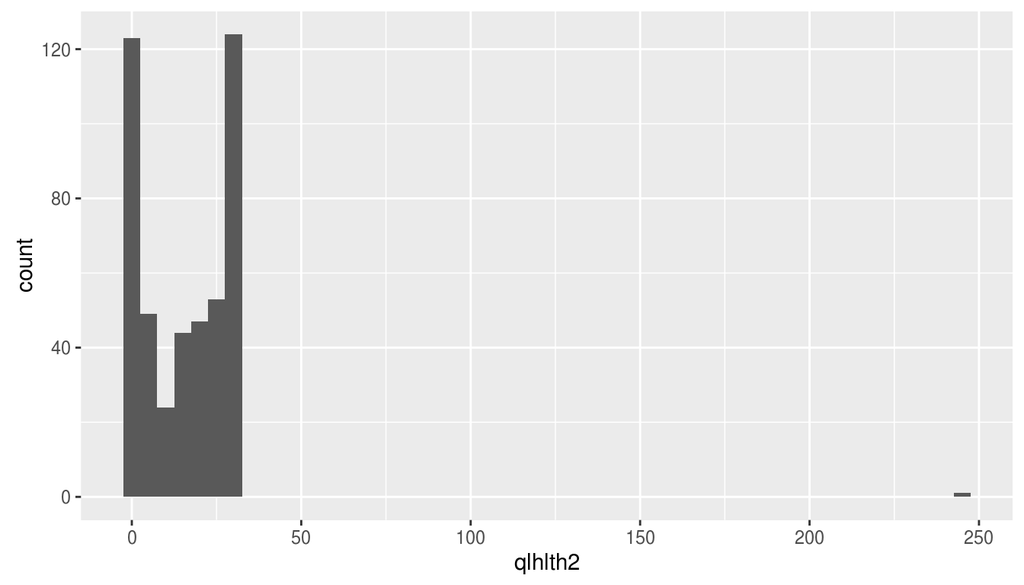

```r
ggplot(data = brfss2013, aes(x = qlhlth2)) +
  geom_histogram(binwidth = 5)
```

This might be an interesting fact, as the majority of occurences is located in extrems.

Let us look at the two variables together.

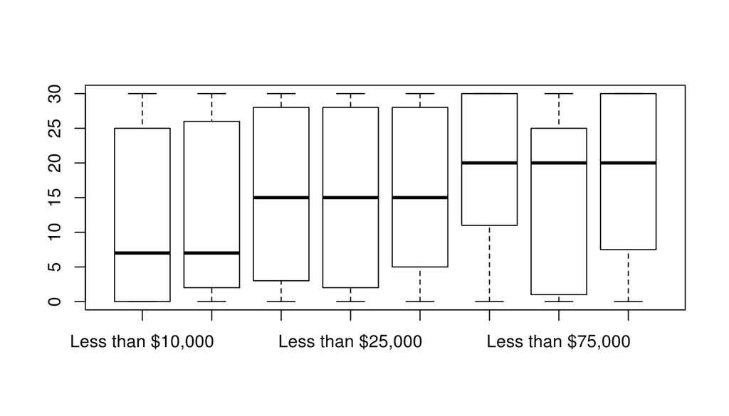

```r
plot(brfss2013$income2, brfss2013$qlhlth2)
```

This plot appears to hint very interesting results. Even though all levels appear to have relatively similar ranges, one can see immediately that median appears to have a positive relationship with the income level. In other words, the higher the income level, the higher the energy level reported.

**Research quesion 3:** Regarding “Social Context” and “Demographics”, does the respondants’ level of income vary according to the number of hours worked?

- Explanatory variable: “scntlwk1” (How Many Hours Per Week Did You Work); variable type: numerical discrete; data type encoding in dataset: int
- Response variable: “income2” (Income Level); variable type: categorical ordinal with 8 levels;

Since we previously already analysed the two variables individually, let us go directly to plotting them together.

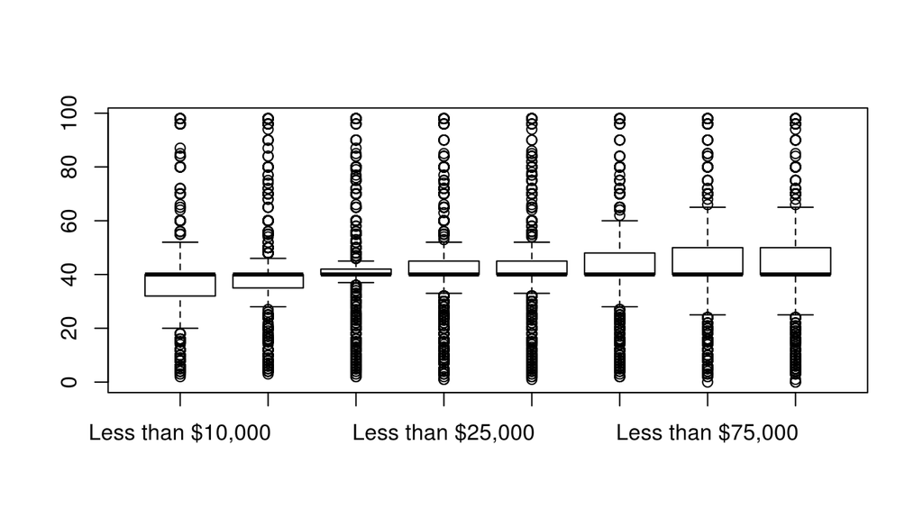

```r
plot(brfss2013$income2, brfss2013$scntlwk1)
```

One might hypothesize about having a higher level of income having a wider and upper range of hours worked, although the author argues that no clear hint is given by the plot.